# Portfolio for Rena Tran n11288353

2023-03-20

# Question 1

**Visualization Title & Link:** [OC] The Cost Of Cable Vs. Top Streaming Subscriptions https://www.reddit.com/r/dataisbeautiful/comments/11u5wn6/oc_the_cost_of_cable_vs_top_streaming/

**Image:**

[figure not shown]

#### A. Describing the context

**Who is the audience or audiences?:**  
The general population who either watches cable TV or using video streaming services for entertainment.

**When can the communication happen, and what tools have been used to suggest an order:**  
All information is present at once as a static image. The size of each bar suggest that there is little difference until the reader examines further by sectioning each streaming service against the cable package.

**How has the data been used to convey the action?:**  
The sections of the streaming services can be compared to the whole of a cable package which, with the benefit of the axis stating ad-free services, allows the author to convey their message of favouring streaming services.

#### B. Genre

**Which of the seven genres listed above best describes the data visualisation?** Annotated Chart.

#### C. Author-driven vs Reader-driven

**Where on the spectrum from author- to reader-driven is this visualisation?** Reader-driven as the author presents the data but it is up for how the reader wants to dissect the information presented.

# Question 2

#### Cheng et al 2017

**What is the main argument of the paper?** The main argument of this paper is that a well-designed Graphical Abstract benefits scientific authors by making them seem more intelligent and the paper interesting to more potential readers. As such, this paper points to the collaboration between scientists and visual design experts to be majorly beneficial for interesting larger audiences.

**According to this paper, why is effective visual communication important (or not)?** By effectively using Graphical Abstract, papers are more interesting, clearly written and gives the author an impression of high intelligence.

**What are the key elements, considerations, or factors to be considered for effective visual communication addresses in the paper? Do you disagree with any?** Some key elements for effective visual communication include analyzing and reducing the complexity of the design to low-mid complexity, having a clear start and end point and highlighting the most important information.

**What pitfalls are identified in the paper that can be avoided if we use effective visual communication?** By using effective visual communication, scientific papers can be more interesting and appeal to a larger audience. It also provides the impression that the paper is clearly written and allow the reader to have a sense of understanding the information more easily.

# Question 3

**Explore the datasets already loaded into your R workspace by typing data(), and use one of these to design a visualisation from the types covered in week 4 that shows variation of tree heights. Justify your choice of dataset, plot type, and variables. Give a short justification for your aesthetic choices and how they make the figure a more effective communication tool.**

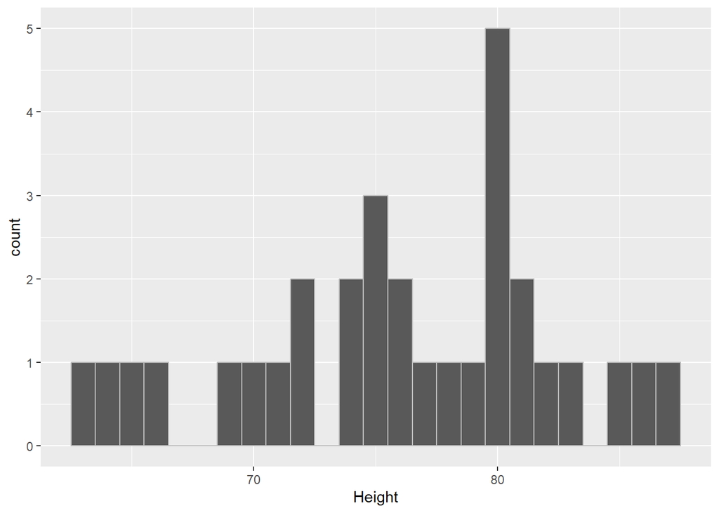

```r
ggplot(data = trees, aes(x= Height)) +
  geom_histogram(binwidth = 1, color="grey")
```

The “trees” dataset in R provides the volume, diameter and height of black cherry trees which allows for an example of tree height variation to be analysed. As such, only the height of the trees needs to be used and was plotted along the x-axis in a histogram to show the distribution of the trees’ height in this dataset. A small aesthetic feature was to split each bar with a gray line for greater visual clarity.*

# Question 4

**Using the covdata dataset from the practical in Week 4, compare the mobility of four countries or regions. Include the code you write to subset the data (make sure it’s being shown in your knitted markdown file by setting echo=TRUE when setting up the markdown code chunk). Justify your choice of plot type and variables. Give a short justification for your aesthetic choices and how they make the figure a more effective communication tool.**

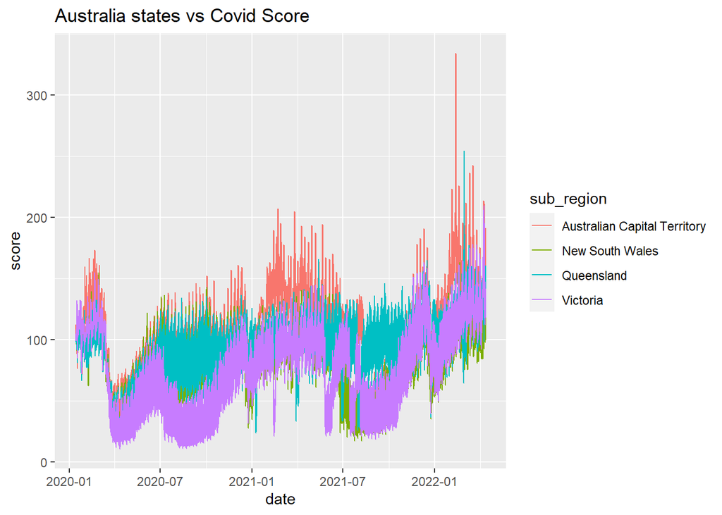

```r
data("apple_mobility")
apple_subset<-apple_mobility %>% filter(country == c('Australia'), sub_region %in% c('Australian Capital Territory', 'Queensland', 'New South Wales', 'Victoria'))

ggplot(data = apple_subset, aes(x=date, y =score))+
  geom_line(aes(colour=sub_region)) +
  ggtitle("Australia states vs Covid Score")
```

This data has been showcased in a time series plot, with the 4 regions faceted by colour for visual clarity to easily discern each region. The data shown is the date along the x-axis and score on the y-axis to show the score of these 4 regions of Australia over time. A line plot allows for these changes to be observed easily as well as showing any substantial peaks and trends over time.

# Question 5

**Explore any of the pre-loaded datasets you like. Choose one that we haven’t explored yet in the unit materials. Produce two plots from the two variable plot types we explored in week 4, justify your choice of plot type and variables, and explain what your audience might discover from that plot. Give a short justification for your aesthetic choices and how they make the figure a more effective communication tool.**

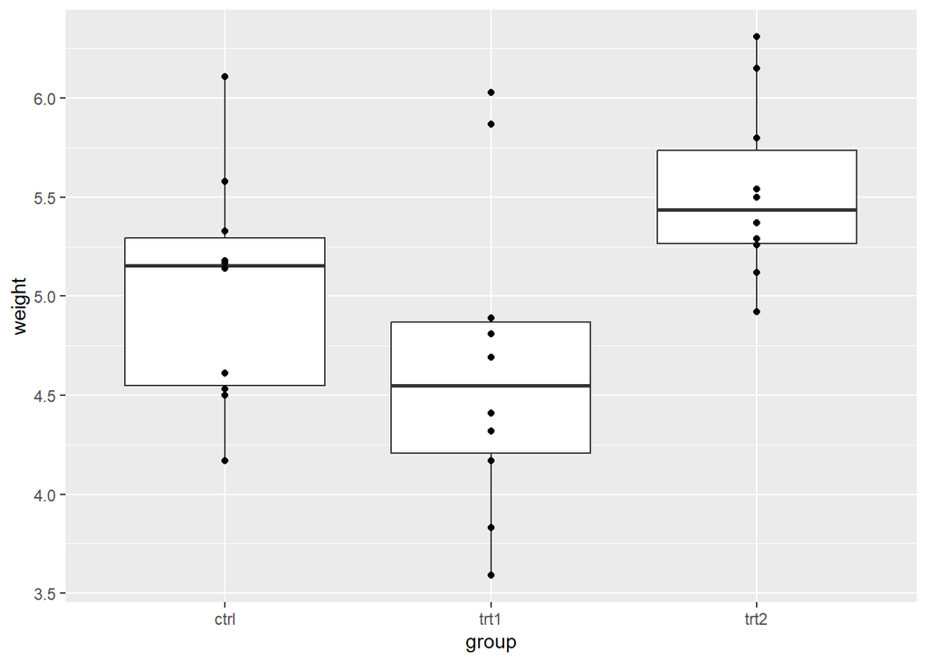

```r
data("PlantGrowth")
ggplot(PlantGrowth, aes(x= group, y= weight))+
  geom_boxplot()+
  geom_point()
```

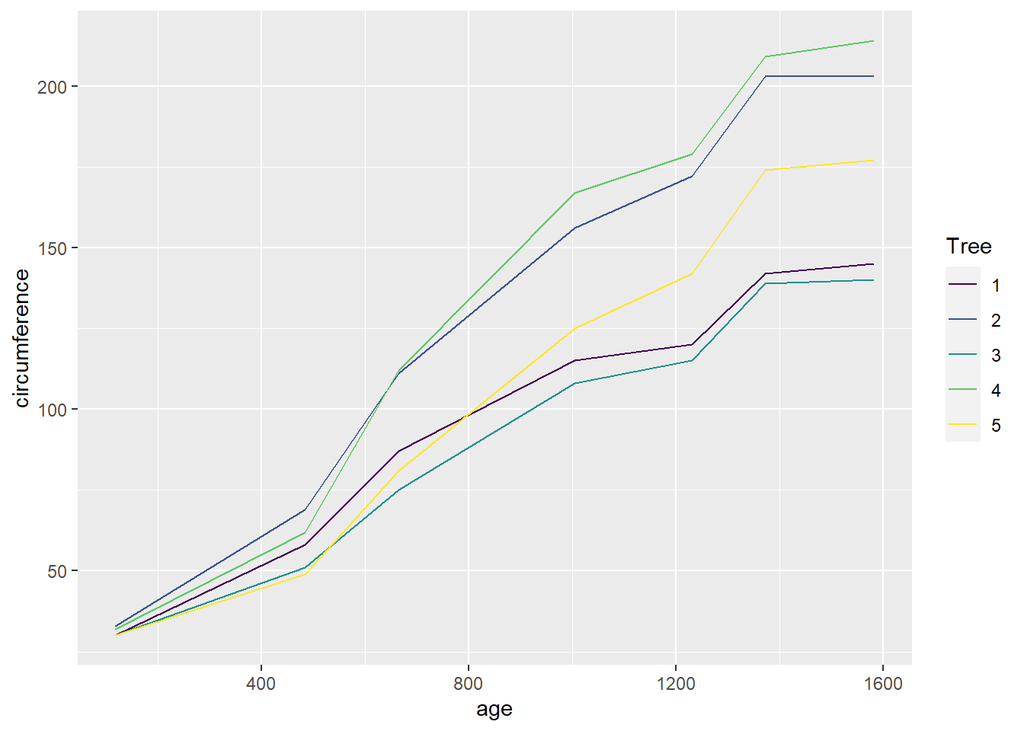

```r
data("Orange")
Orange$Tree<- factor(Orange$Tree, levels = c(1,2,3,4,5))
ggplot(data = Orange, aes(x= age, y= circumference))+
  geom_line(aes(colour = Tree))
```

# Question 6

**Create two bubble plots (a.k.a multi-dimensional scatterplot) using the dataset downloaded by**

```r
gender_pay_gap <- read.csv(
  "https://raw.githubusercontent.com/plotly/datasets/master/school_earnings.csv")
```

**First, make the bubble plot you think is most useful.**

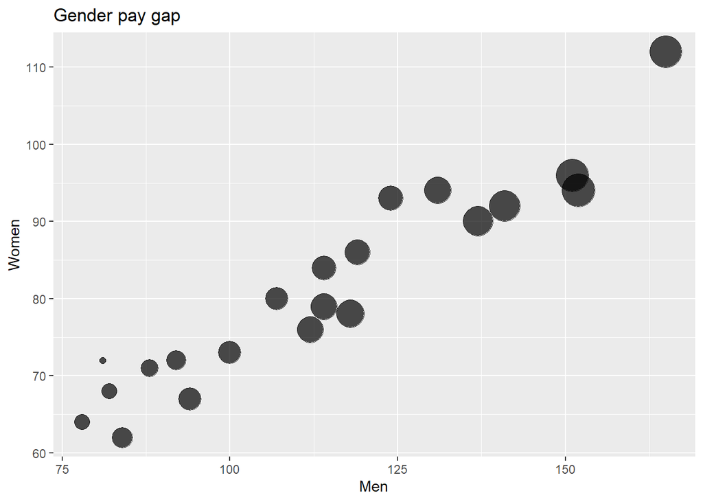

```r
ggplot(gender_pay_gap, aes(x= Men, y= Women, size = Gap))+
  geom_point(alpha=0.7)+
  theme(legend.position="none")+
  scale_size(name="size",range=c(2,11))+
  ggtitle("Gender pay gap")
```

**Second, add at least one more variable/preattentive attribute to your plot.**

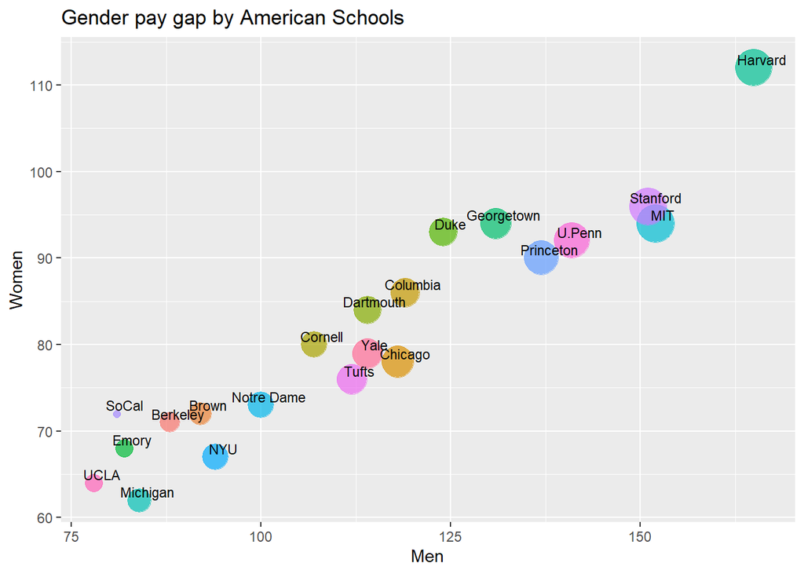

```
1. what do you think is the first observation a reader makes from the second plot?
```

```r
ggplot(gender_pay_gap, aes(x= Men, y= Women, size = Gap, color = School))+
  geom_point(alpha=0.7)+
  geom_text(label= gender_pay_gap$School , size = 3, color= "black", nudge_y=1, nudge_x=1)+
  scale_size(name="size",range=c(2,11))+
  theme(legend.position="none")+
  ggtitle("Gender pay gap by American Schools")
```

The first observation readers would observe would be the colours tied to the data points of different schools with larger points indicating a larger gender pay gap.

```
2. why have you chosen to match the variable with the preattentive attributes you have chosen in the first plot?
```

Adding School with the colour adds another dimension of context for the visulisation which allows readers to extract more information from the data as larger circles with that school means a larger gender pay gap.

```
3. what audience might you use your first plot for vs your second?
```

# Question 7

**Using faceting to explore the relationship between C02 uptake, concentration, and plant using the CO2 dataset.**

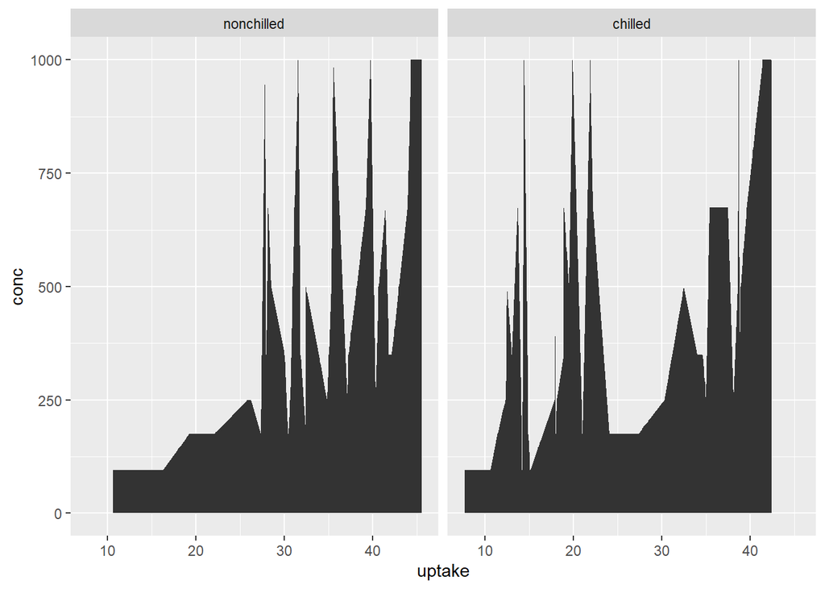

```r
data("CO2")
ggplot(data = CO2, aes(x=uptake, y= conc, group=Treatment))+
  geom_area() +
  facet_wrap(~Treatment)
```

```r
head(CO2)
```

```
##   Plant   Type  Treatment conc uptake
## 1   Qn1 Quebec nonchilled   95   16.0
## 2   Qn1 Quebec nonchilled  175   30.4
## 3   Qn1 Quebec nonchilled  250   34.8
## 4   Qn1 Quebec nonchilled  350   37.2
## 5   Qn1 Quebec nonchilled  500   35.3
## 6   Qn1 Quebec nonchilled  675   39.2
```

```
1.what do you think is the first observation a reader makes from the plot?
```

The first observations will make for the plots is that, as the uptake increases, there is an increasing amount of spikes in the concentration. However the difference between Chilled and nonchilled is stagerring as it can be see n that nonchilled does not have these peaks until around 30 uptake while chilled begins as early as 14 uptake.

```
2.why/why not is faceting an effective way to visualise this data to see these relationships?
```

Facetting is an effective way to distinguish data in this plot as without facetting the data points would be merged together and without overlapping with colour or another preattentive attribute near impossible for the reader to distinguish.

```
3.what is another visualisation option (you do not need to make this plot)?
```

Another visulisation option may be a scatter plot to see how scattered the data is with a line of best fit to loosely represent the relationship, as it can be seen in the current area plot that the lines are very sharp and doesn’t look that nice to be honest.

# Question 8

**Create one visualisation using any of those three datasets, of either: heat map, radar plot, alluvial**

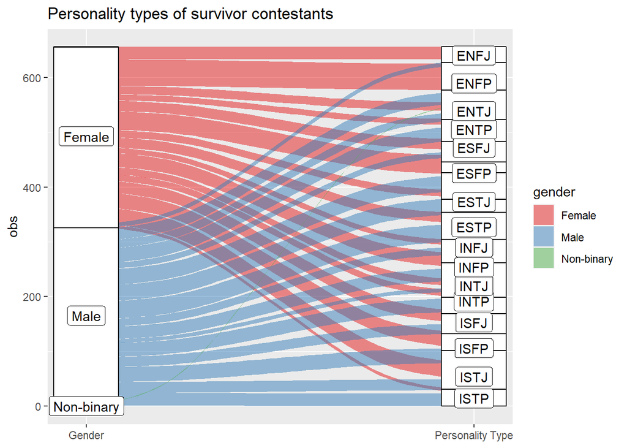

```
1. what do you think is the first observation a reader makes from the plot?
```

```r
alluvial<- castaway_details%>% filter(!is.na(personality_type)) %>%
  group_by(gender, personality_type) %>%
  summarise(obs=n())%>%
  ggplot(aes(y= obs, axis1= gender, axis2 = personality_type)) +
  geom_alluvium(aes(fill= gender), width = 0)+
  geom_stratum(width=1/6, reverse =FALSE)+
  geom_label(stat="stratum", aes(label= after_stat(stratum)), vadjust= -3)+
  scale_x_discrete(limits=c("Gender", "Personality Type"), expand = c(.05, .05))+
  scale_fill_brewer(type="qual", palette = "Set1")+
  ggtitle("Personality types of survivor contestants")
alluvial
```

The first observation that readers will make is by observing it from thwe top seeing that the largest number of people who are an ENFP are also female as they have the largest ribbon comparatively to every other ribbon.

```
2. why/why not is your chosen plot type an effective way to visualise this data to make this comparison?
```

An alluvial plot is an effective way of showing the transition of different variables to another, with the dataset of the castaway details including more gender identities than female and male, it is effective at including them as opposed to a dumbbel plott.

```
3. what is another visualisation option (you do not need to make this plot)?
```

Another visulation option that could have been made would be to facet the personality types by extroverted and introverted. This would allow the readers to more easily observe the ribbons and avoid overplotting.

# Question 9

```r
tuesdata <- tidytuesdayR::tt_load(2021, week = 15)
```

```
## --- Compiling #TidyTuesday Information for 2021-04-06 ----
```

```
## --- There are 5 files available ---
```

```
## --- Starting Download ---
```

```
## --- Download complete ---
```

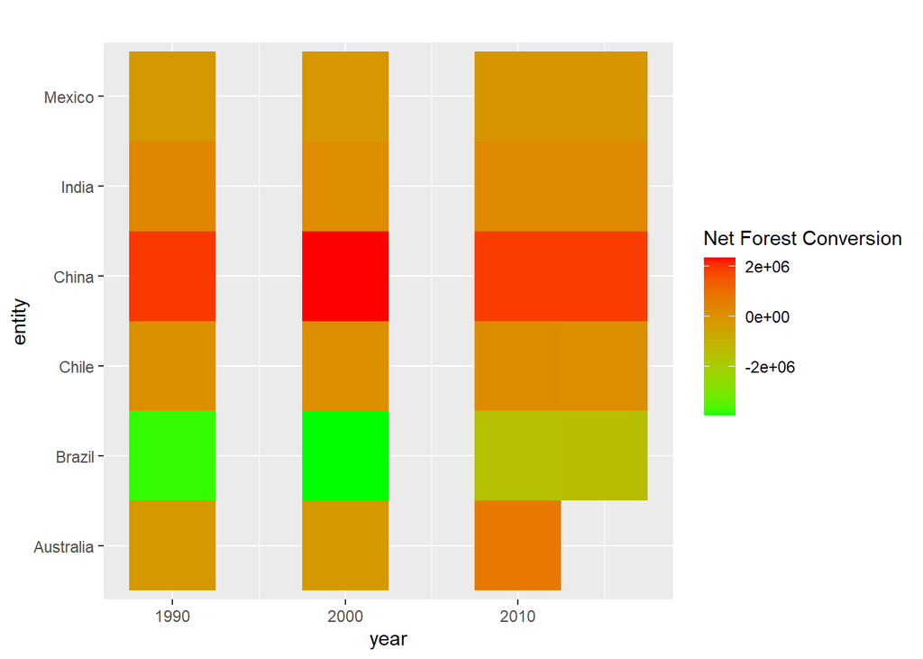

```
1. what do you think is the first observation a reader makes from the plot?
```

```r
forest<- tuesdata$forest %>% filter(entity == "Australia" | entity == "China" | entity =="United State" | entity == "India" | entity == "Brazil" | entity == "Mexico" | entity == "Chile")
forest2<- tuesdata$forest %>% filter( entity != "World", net_forest_conversion != 0)

ggplot(forest, aes(x= year, y= entity)) +
  geom_tile(aes(fill= net_forest_conversion))+
  scale_fill_continuous(low = "green", high = "red")+
  ggtitle("") + labs(fill="Net Forest Conversion")
```

The first observations a reader will make is the outstanding red of china’s net forest conversion versus every other country.

```
2. why/why not is your chosen plot type an effective way to visualise this data to make this comparison?
```

```
3. what is another visualisation option (you do not need to make this plot)?
```

Another visulisation option for this dataset could be a bar plot to represent the amount of deforestation in each country with specific data points at. This could then also be visualised with the years by multiple bars to illustrate the years.

# Question 10

[output not shown]

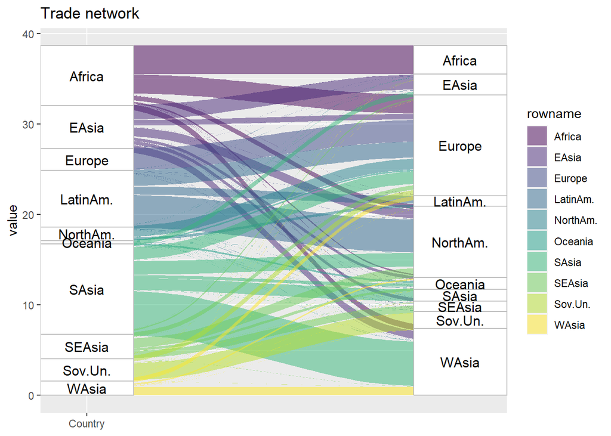

```
2. In 1-2 sentences, propose any differences in the who/what/when context between these two visualisations.
```

```r
data <- read.table("https://raw.githubusercontent.com/holtzy/data_to_viz/master/Example_dataset/13_AdjacencyDirectedWeighted.csv", header=TRUE)

colnames(data) <- c("Africa", "EAsia", "Europe", "LatinAm.",   "NorthAm.",   "Oceania", "SAsia", "SEAsia", "Sov.Un.", "WAsia")
rownames(data) <- colnames(data)

data_long <- gather(rownames_to_column(data), key='key', value='value', -rowname)
mycolor <- viridis(nrow(data))

alluvial1<- data_long %>%
  ggplot(aes(y= value, axis1= rowname, axis2 = key, label = key)) +
  geom_alluvium(aes(fill= rowname), width = 1/12)+
  geom_stratum(width=1/4, fill = "white", color = "grey")+
  geom_text(stat="stratum", size =4 , aes(label = after_stat(stratum)))+
  scale_x_discrete(limits=c("Country", "Country"), expand = c(.05, 0))+
  scale_fill_manual(values= mycolor)+
  ggtitle("Trade network")
alluvial1
```

```
3. How have your aesthetic choices improved an audiences’ understanding of the visualisation, and helped to communicate within this context?
```

```
4. Describe (but do not implement) a different visualisation that can communicate the same message with the same variables in the data. How might this other visualisation be more effective than this alluvial visualisation?
```

A network graph showing the connections from country to country can show the same data effectively by giving the audience a visulisation on how these countries connect and trade with eachother without the overwhelming the audience with the content of the world map.

```
5. Describe (but do not implement) a different visualisation that can communicate the same message, which includes additional information/data that can expand the message. You do not need to find this data, but please describe it. How might this other visualisation be more or less effective than this alluvial visualisation?
```

Possibly a layer of context which could be encoded into a visulisation of this type would be network trades with colours representing the biggest export for that country. Arrows would be one way representing that export to the country.

# Question 11

```r
attr1 <- read.csv("data/attr_farms.csv", stringsAsFactors = F) #load the edgelist_farms.Rdata
edges <- read.csv("data/Edgelist_farms.csv", stringsAsFactors = F) #load attr.farms.Rdata
```

```
1. Consider the cattle network from this week’s workshop. Create a network visualisation where vertex size is used to represent the size of the farm in some way. Your plot will be assessed for accuracy and effectiveness, so design your visualisation and use pre-attentive attributes carefully.
```

```r
net_edges <- graph.data.frame(edges,directed=T)
V(net_edges)$type <- as.character(attr1$type[match(V(net_edges)$name,attr1$farm.id)])
V(net_edges)$farm.size <- attr1$size[match(V(net_edges)$name,attr1$farm.id)]
V(net_edges)$color <- V(net_edges)$type
head(V(net_edges)$color)
```

```
## [1] "Fattening" "Dairy"     "Fattening" "Dairy"     "Dairy"     "Dairy"
```

```r
V(net_edges)$color <- gsub("Fattening","steelblue1",V(net_edges)$color)
head(V(net_edges)$color)
```

```
## [1] "steelblue1" "Dairy"      "steelblue1" "Dairy"      "Dairy"
## [6] "Dairy"
```

```r
V(net_edges)$color <- gsub("Dairy","darkgoldenrod1",V(net_edges)$color)
head(V(net_edges)$color)
```

```
## [1] "steelblue1"     "darkgoldenrod1" "steelblue1"     "darkgoldenrod1"
## [5] "darkgoldenrod1" "darkgoldenrod1"
```

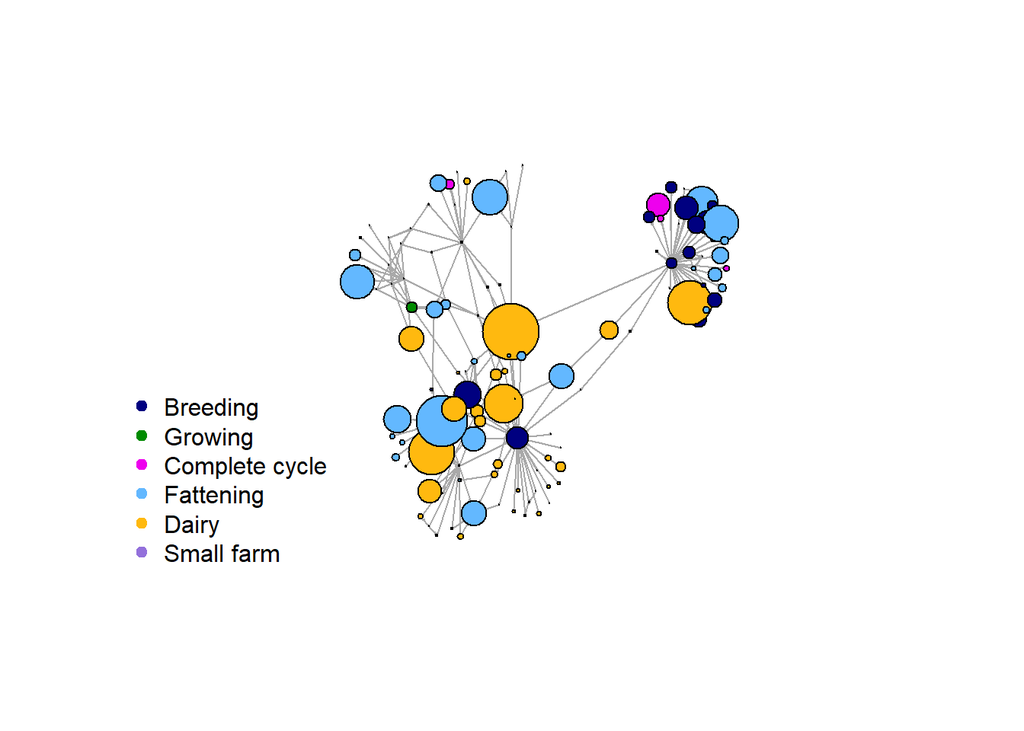

```
2. Do you notice any patterns about where large farms are located within the network?
```

```r
V(net_edges)$color <- gsub("Small farm","mediumpurple",V(net_edges)$color)
V(net_edges)$color <- gsub(pattern="Breeding",replacement="navy",x=V(net_edges)$color)
V(net_edges)$color <- gsub(pattern="Complete cycle",replacement="magenta2",x=V(net_edges)$color)
V(net_edges)$color <- gsub(pattern="Growing",replacement="green4",x=V(net_edges)$color)

plot.igraph(simplify(net_edges),
    layout=layout.fruchterman.reingold,
    vertex.label=NA,
    vertex.color=V(net_edges)$color,
    vertex.size=V(net_edges)$farm.size/75,
    edge.arrow.size=.05)

#make a legend
legend("bottomleft",
    legend=c("Breeding","Growing","Complete cycle","Fattening","Dairy","Small farm"),
    col=c("navy","green4","magenta2","steelblue1","darkgoldenrod1","mediumpurple"),
    pch=19,cex=1,bty="n")
```

Large farms are generally located around clusters where there are vertexes are the most present, the most common ones appear to be fattening farms or dairy farms.

```
3. Describe the message being communicated with this visualisation, and who the audience is.
```

The message of this visulisation is to show where large farms are located, what type of farm they may be and what kind of farms may be near these large farms. The audience for this may be farmers who are interested in planning for their farm.

```
4. How have your aesthetic choices improved an audiences’ understanding of the visualisation, and helped to communicate within this context?
```

By adding changing the vertex size dependent on the farm, this has improved the audiences’ understanding of the visulisation by showing what type of farms are the biggest farms and what farms surround and connect to those farms.

```
5. Suggest (but do not implement) a different visualisation that can communicate the same message – either with the same variables in the data, or suggest additional information that would be useful. How might this other visualisation be more or less effective than this network visualisation?
```

This visulisation could be represent more effectively via an interactive network graph as it would allow reader’s to infer more data, i.e. hovering a large farm to see the size of it and to zoom in further to see smaller farms which are lost in detail on this network graph.

# Question 12

**Create a map using the data contained in rnaturalearth with a map extent that is smaller than the entire world (e.g. only shows one continent, or is bounded in some other way). Colour polygons according to some aspect of the data. In the workshop you created the entire world coloured by the square root of the total population, so you cannot visualise population count for this question. Then, represent that same data using at least one other plot type that we learned earlier in the unit, very briefly (one sentence) identify a target audience and an intended message for each of your two visualisations. Note whether they serve the same purpose, or work best when presented together.**

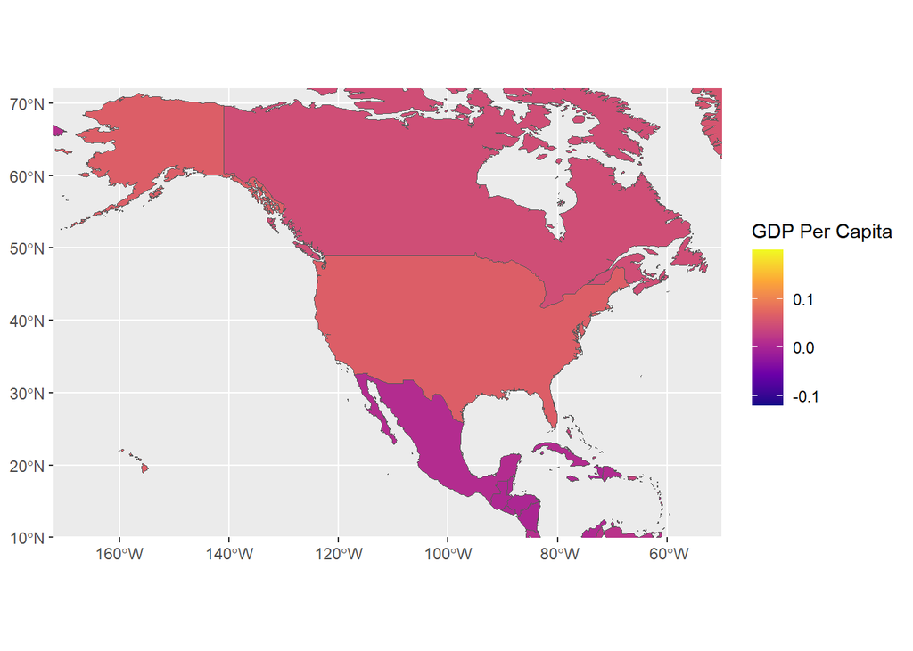

```r
world <- ne_countries(scale = "medium", returnclass = "sf")
NorthAmerica<- filter(world, sovereignt == "United States of America" | sovereignt == "Canada" | sovereignt == "Mexico" | sovereignt == "Greenland" | sovereignt == "Cuba")
NorthAmericas <- NorthAmerica[order(NorthAmerica$gdp_md),]
ggplot(data = world) +
    geom_sf(aes(fill=gdp_md/pop_est))+
            coord_sf(xlim = c(-172, -50), ylim = c(10, 72), expand = FALSE)+
  scale_fill_viridis_c(option = "plasma") + labs(fill ="GDP Per Capita")
```

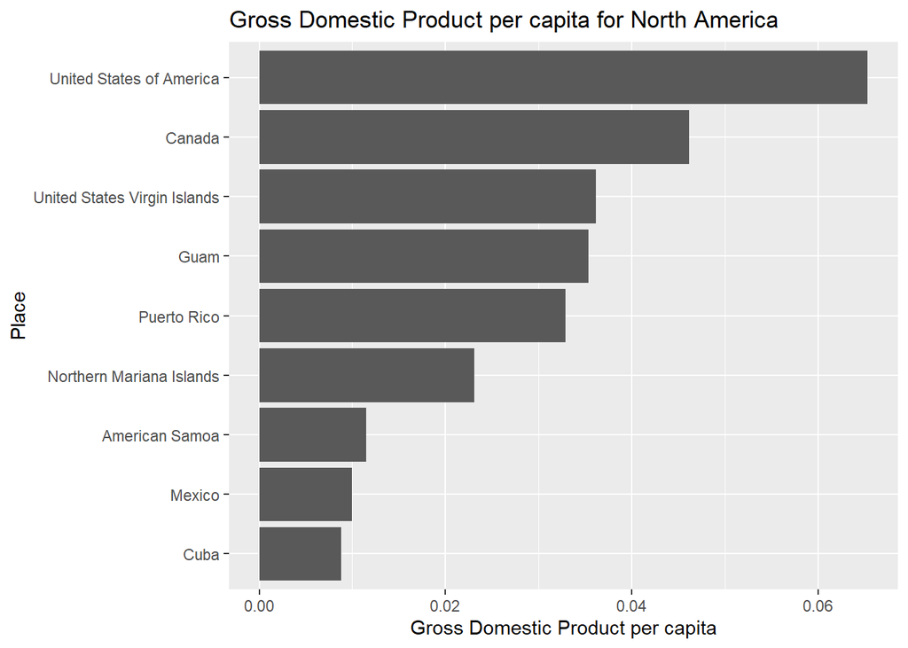

```r
ggplot(data = NorthAmericas, aes(x= reorder(admin, gdp_md/pop_est), y= gdp_md/pop_est))+
  geom_bar(stat="identity") +
  xlab("Place") + ylab("Gross Domestic Product per capita") + ggtitle("Gross Domestic Product per capita for North America")+coord_flip()
```

These two visualizations represent the GDP of the North American Continent through a map which allows readers to relate the data to visual geographical locations and a bar plot which allows easier readbility between low gdp and high gdp through the bars. Though the first visulisation is for audiences who may not be specifically looking at America as the colour ranks the country based on the GDP per capita against the whole world while the bar plot looks specifically at the North American region. These work great together as this porition of the world map would work much better with the whole world to relate to, so with the bar plot the audience is able to specifically look at North America in relation to itself.

# Question 13

Reproduce the following map using these locations and transport datasets Download these locations and transport datasets. In the dataset, one row represents the sale of one barrel of whiskey (this is made up data!). You’ll need to draw from your past experiences in this unit wrangling data and changing elements of the ggplot outputs. Remember the textbook you have used in earlier workshops - this will be very valuable for manipulating the data. Also explore the help file for the count() function, and the help file for ‘Efficiently bind multiple data frames by row and column’ using the package dplyr.

```r
whisk.locations<-read.csv("whiskey_data/tas_locations.csv")
whisk.locations[nrow(whisk.locations)+1,] <- c("Devonport",146.3452, -41.1771)
whiskey.locations<-whisk.locations[order(whisk.locations$place),]
whisk.sales<-read.csv("whiskey_data/whiskey_sales_tasmania.csv")
```

```r
whiskey.consumer<- whisk.sales%>% group_by(consumer)%>%summarise(obs=n())
whiskey.consumer.total<- c("Consumer","Consumer","Consumer","Consumer","Consumer","Consumer","Consumer")
whiskey.producer<- whisk.sales%>% group_by(producer)%>%summarise(obs=n())
whiskey.producer.total<- c("Producer","Producer","Producer","Producer","Producer","Producer","Producer","Producer")
whiskey.cool<- data_frame(place=c(whiskey.consumer$consumer, whiskey.producer$producer),
                          type = c(whiskey.consumer.total, whiskey.producer.total),
                     sales = c(whiskey.consumer$obs, whiskey.producer$obs))
```

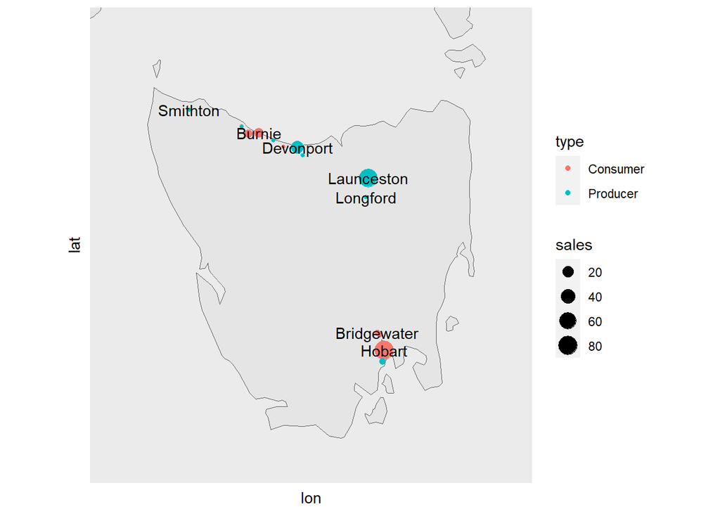

```r
whiskey.sorted<- whiskey.cool[order(whiskey.cool$place),]
whiskey<-cbind(whiskey.sorted, whiskey.locations)
whiskeys<- st_as_sf(whiskey, coords = c("lon", "lat"), crs= 4326, agr ="place")

world<- ne_countries(scale = "medium", returnclass = "sf")

ggplot(data=world)+
  geom_sf()+
  geom_sf(data = whiskeys, aes(size = sales, color = type))+
  geom_sf_text(data= whiskeys, aes(label = place), check_overlap = TRUE)+
  coord_sf(xlim = c(144, 149), ylim = c(-44, -40), expand = FALSE)+
  xlab("lon")+ ylab("lat") +
  theme(axis.text.x = element_blank(), axis.text.y = element_blank(), axis.ticks.y = element_blank(), axis.ticks.x = element_blank(), panel.grid.major = element_blank(), panel.grid.minor = element_blank())
```

Improve upon this visualisation to be more effective at communicating a message. Identify the audience and the message, and justify your visualisation choices within that context. Include both visualisations (the one from part (a) and part (b))

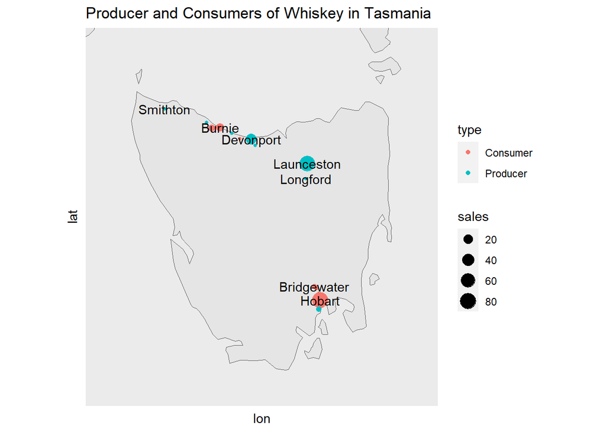

```r
ggplot(data=world)+
  geom_sf()+
  geom_sf(data = whiskeys, aes(size = sales, color = type))+
  geom_sf_text(data= whiskeys, aes(label = place), check_overlap = TRUE)+
  coord_sf(xlim = c(144, 149), ylim = c(-44, -40), expand = FALSE)+
  xlab("lon")+ ylab("lat") + ggtitle("Producer and Consumers of Whiskey in Tasmania")+
  theme(axis.text.x = element_blank(), axis.text.y = element_blank(), axis.ticks.y = element_blank(), axis.ticks.x = element_blank(), panel.grid.major = element_blank(), panel.grid.minor = element_blank())
```

Adding a title is an important visulisation option as without it there is no context to what is being consumed or produced, it could be like cheese or croutons. This is very much aimed at people who are interested in seeing the market for whiskey in Tasmania as they can see how much is being produced and sold in their respective location.

Visualise this data using another type of visualisation style we have examined in previous weeks. Explain how the audience is different between your maps in part (b) and (c).

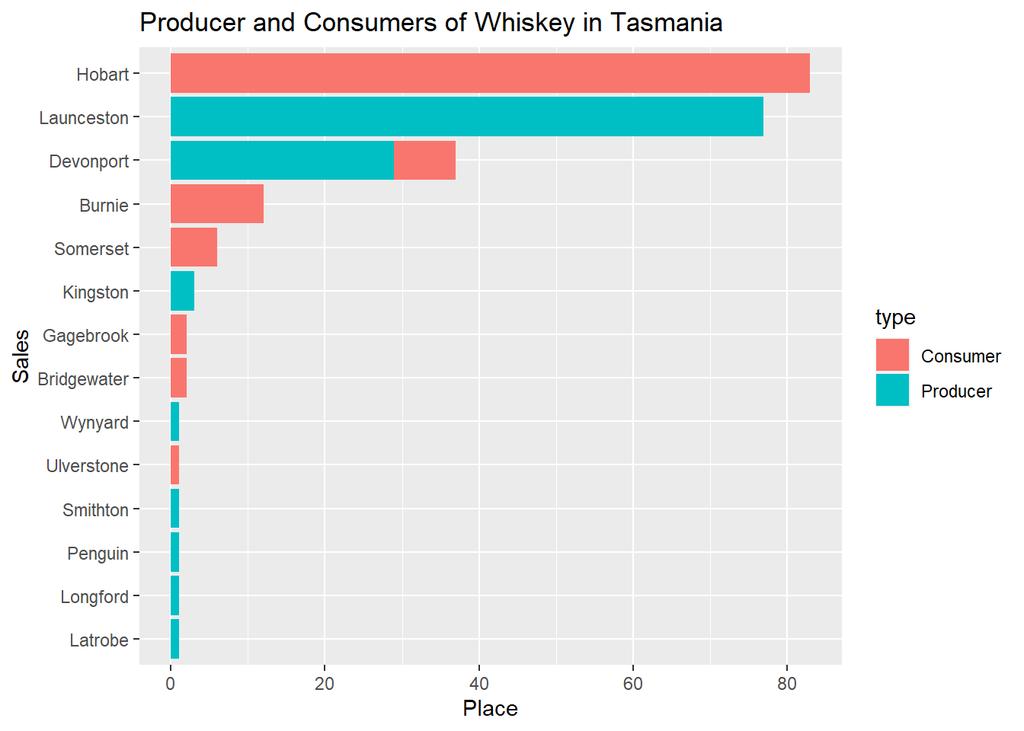

```r
whiskeyss <- whiskeys[order(whiskeys$sale),]


ggplot(whiskeyss, aes(x=reorder(place,sales), y=sales, fill=type))+
  geom_bar(stat="identity")+ coord_flip() + xlab("Sales") +ylab("Place") + ggtitle("Producer and Consumers of Whiskey in Tasmania")
```

The audience for this visulisation is different as without the location to refer to, this is better fit for someone who is familliar with Tasmania’s locales.

# Question 14

Create two maps showing two different invasive plants – one which has a larger distribution than the other. Create numeric breaks in the colours that make sense given the distribution of the data. Customise the visualisation based on the workshop in Week 10, and justify how your choices (including the numeric breaks) have made your visualisations more effective.

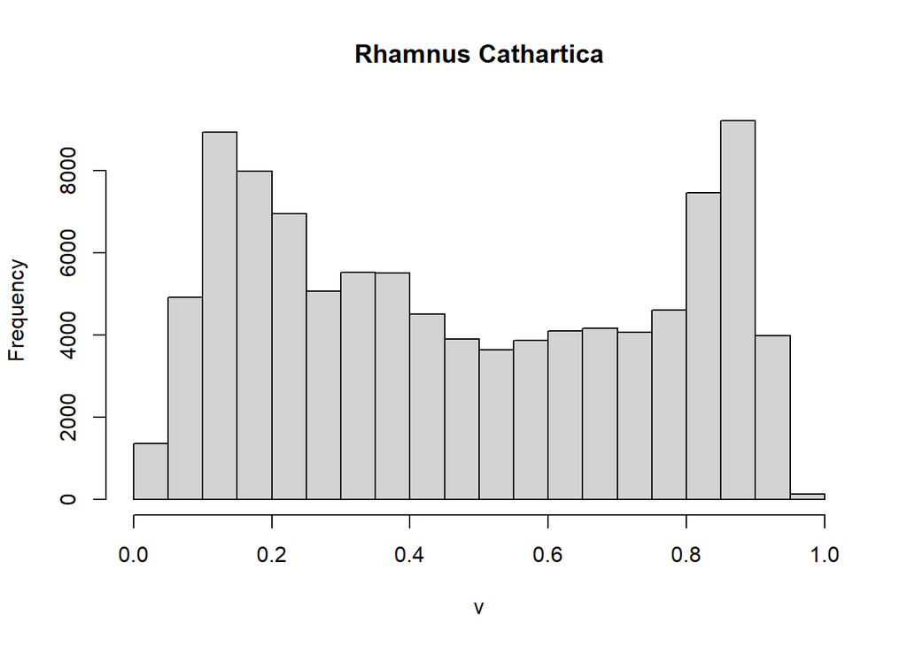

```r
DEM <- raster("data/sumrast_allassumptions.avg_Rhamnus cathartica.tif")
DEM2<- raster("data/sumrast_allassumptions.avg_Rosa multiflora.tif")
DEM<- setMinMax(DEM)
hist(DEM, main ="Rhamnus Cathartica")
```

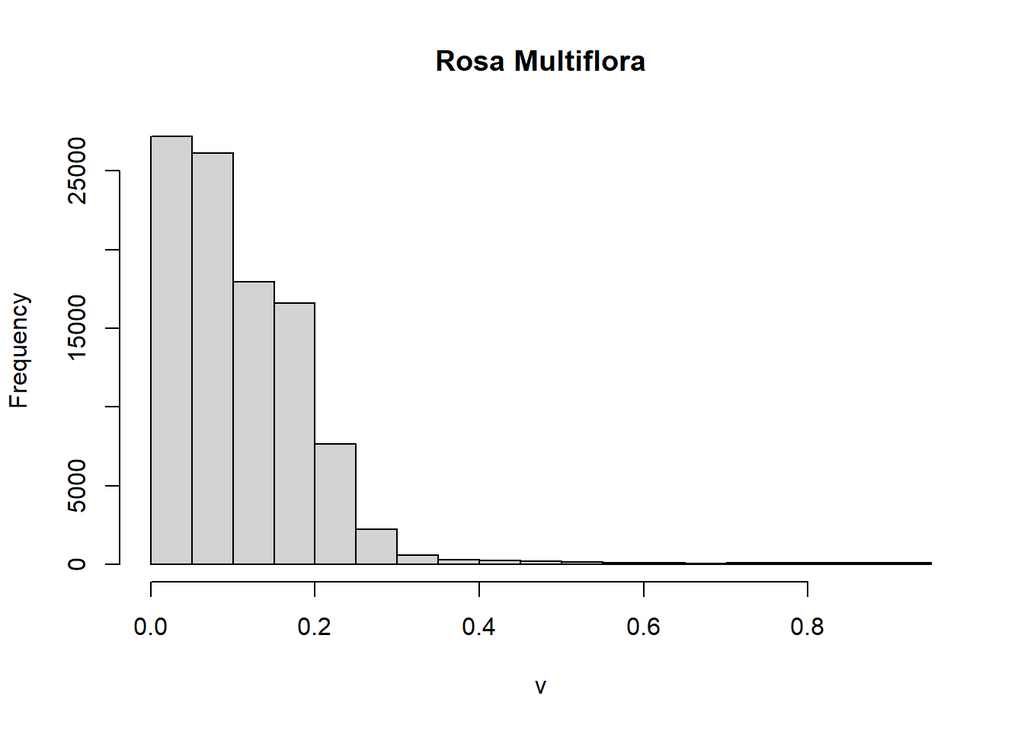

```r
hist(DEM2, main="Rosa Multiflora")
```

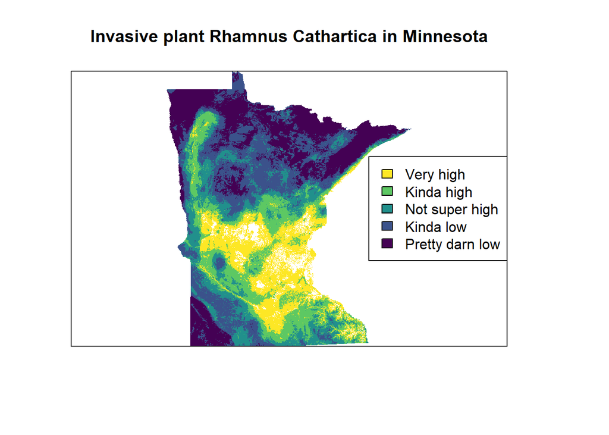

```r
brk <- c(0,0.2, 0.4, 0.6, 0.8, 0.9)
col<- viridis(5)

plot(DEM, breaks = brk, col=col, legend = FALSE, main = "Invasive plant Rhamnus Cathartica in Minnesota", ylab="",xlab="", yaxt="n", xaxt="n")
legend( "right",
        legend = c("Very high", "Kinda high", "Not super high","Kinda low", "Pretty darn low"),
        fill = rev(col))
```

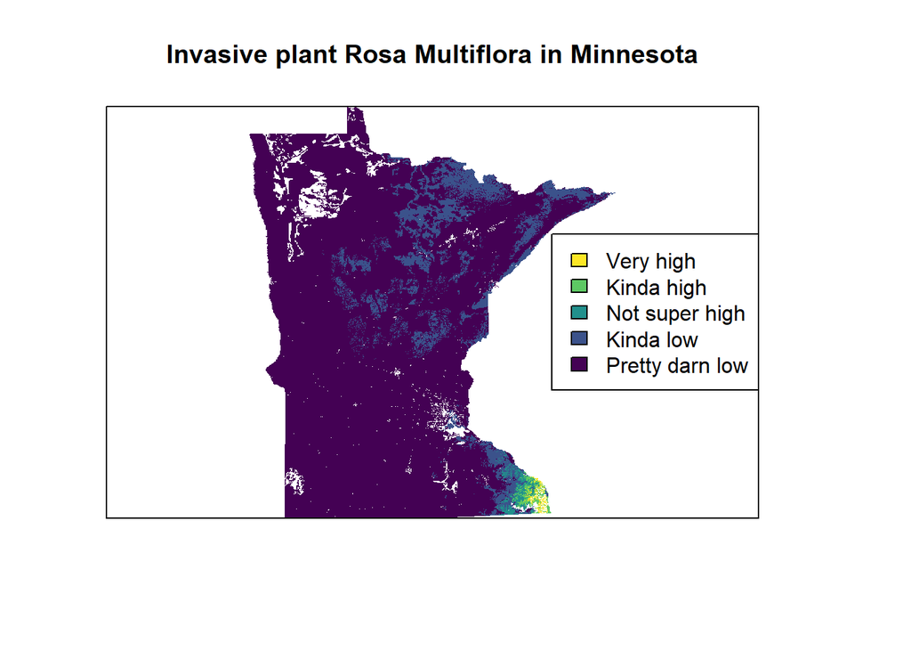

```r
plot(DEM2, breaks = brk, col=col, legend = FALSE, main = "Invasive plant Rosa Multiflora in Minnesota", ylab="",xlab="", yaxt="n", xaxt="n")
legend( "right",
        legend = c("Very high", "Kinda high", "Not super high","Kinda low", "Pretty darn low"),
        fill = rev(col))
```

The important visulisation option, numeric breaking of the colours, allows the data to have this visual effect where the high intensity areas are lightly coloured while areas with less activity are dull and darker. It can be seen the transition from a low area to high area as there is a clear transition from ‘Pretty Darn Low’ areas to ‘Very High’ areas. Adding a legend just makes sure there is no confusion with this and a title to give context as not everyone may know what plant this is or what it does, or that this is Minnesota.

# Question 15

You are a data scientist working with the Minnesota Department of Natural Resources who are trying to decide which invasive plant to control first. They are seeking your recommendation, which must be supported by data. You are armed with your maps from the previous question. Create one other, non-spatial, simple visualisations which can help illustrate your argument for which of the two invasive plants is the biggest problem (this might have two panels – one for each of the two species). Write a 3 sentence argument that you’ll make to the Department to convince them of your recommendation, referring to your maps and your figures from this question.

It can be seen from the two histograms for these two invasive plants that Rhamnus Carthartica has a more spread distribution across all of Minnesota with high activity clustering around the centre of Minnesota. While Rosa Multiflora has a heavy right tail across all of Minnesota with a small high activity cluster at the most South-eastern corner of Minnesota. As such it would be hard to target Rosa Multiflora directly and would prove not as beneficial as controlling Rhamnus Cathartica which has higher activity spreading across a lot of the centre of Minnesota.